# Causal Model Selection Hypothesis Tests in Systems Genetics: a tutorial

Elias Chaibub Neto and Brian S. Yandell

3/17/2017

## Motivation

Current efforts in systems genetics have focused on the development of statistical approaches that aim to disentangle causal relationships among molecular phenotypes in segregating populations. Model selection criterions, such as the AIC and BIC, have been widely used for this purpose, in spite of being unable to quantify the uncertainty associated with the model selection call. In this tutorial we illustrate the use of software implementing the causal model selection hypothesis tests proposed by Chaibub Neto et al. (2012).

## Overview

This tutorial illustrates the basic functionality of the CMST routines in the `qtlhot` R package using few simulated toy examples. The analysis of a yeast genetical genomics data-set presented in Chaibub Neto et al. (2012) is reproduced in a separate package, `R/qtlyeast`. The `R/qtlhot` package depends on `R/qtl` (Broman et al. 2003), and we assume the reader is familiar with it.

## Basic functionality

Here, we illustrate the basic functionality of the CMST routines in the `R/qtlhot` package in a toy simulated example.

```r
library(CausalMST)
```

```r
set.seed(987654321)
CMSTCross <- SimCrossCausal(n.ind = 100,
                        len = rep(100, 3),
                        n.mar = 101,
                        beta = rep(0.5, 2),
                        add.eff = 1,
                        dom.eff = 0,
                        sig2.1 = 0.4,
                        sig2.2 = 0.1,
                        eq.spacing = FALSE,
                        cross.type = "bc",
                        normalize = TRUE)
```

We compute the genotype conditional probabilities using Haldane’s map function, genotype error rate of 0.0001, and setting the maximum distance between positions at which genotype probabilities were calculated to 1cM.

```r
CMSTCross <- qtl::calc.genoprob(CMSTCross, step = 1)
```

We perform QTL mapping using Haley-Knott regression (Haley and Knott 1992), and summarize the results for the 3 phenotypes. Figure presents the LOD score profiles for all 3 phenotypes. The black, blue and red curves represent the LOD profiles of phenotypes $y_1$, $y_2$ and $y_3$, respectively.

```r
Scan <- qtl::scanone(CMSTCross, pheno.col = 1 : 3, method = "hk")
summary(Scan[, c(1, 2, 3)], thr = 3)
```

```
##          chr pos   y1
## c1.loc55   1  55 12.6
```

```r
summary(Scan[, c(1, 2, 4)], thr = 3)
```

```
##          chr pos   y2
## c1.loc55   1  55 5.27
```

```r
summary(Scan[, c(1, 2, 5)], thr = 3)
```

```
##       chr  pos   y3
## D1M50   1 55.5 7.58
```

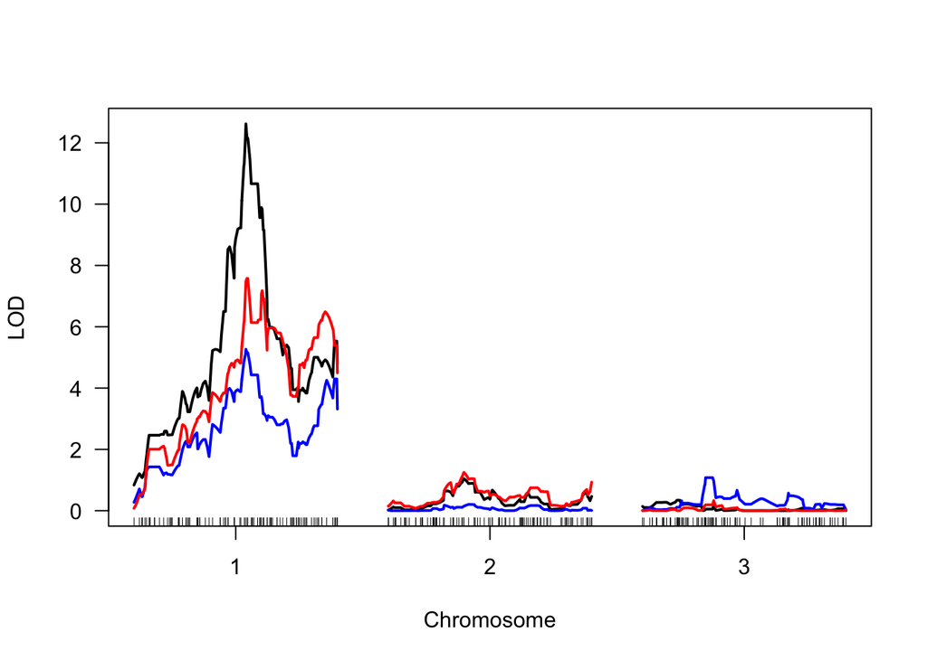

```r
plot(Scan, lodcolumn = 1 : 3, ylab = "LOD")
```

LOD score profiles for phenotypes $y_1$ (black curve), $y_2$ (blue curve) and $y_3$ (red curve).

Phenotypes $y_1$ and $y_2$ map to exactly same QTL at position 55 cM on chromosome 1. Phenotype $y_3$ maps to a QTL at position 55.5 cM. Whenever two phenotypes map to close, but not exactly identical, positions we are faced with the question of which QTL to use as causal anchor. Instead of making a (sometimes) arbitrary choice, our approach is to compute the joint LOD profile of both phenotypes and use the QTL detected by this joint mapping approach as the causal anchor. This is pursued in package R/qtlhot.

Now, we fit our causal model selection tests for phenotypes $y_1$ and $y_2$ using the `CMSTtests` function. The `Q.chr` and `Q.pos` arguments specify the chromosome and position (in cM) of the QTL to be used as a causal anchor. The argument `method` specify which version of the CMST test should be used. The options `"par"`, `"non.par"` and `"joint"` represent, respectively, the parametric, non-parametric, joint parametric versions of the CMST test. The option `"all"} fits all three versions. The`penalty`argument specifies whether we should test statistics based on the AIC (`“aic”`), BIC (`“bic”`), or both (`“both”`) penalties. In this particular call we computed all 3 versions using both penalties fitting 6 separate CMST tests.

```r
nms <- names(CMSTCross$pheno)
out1 <- CMSTtests(CMSTCross,
                  pheno1 = nms[1],
                  pheno2 = nms[2],
                  Q.chr = 1,
                  Q.pos = 55,
                  addcov1 = NULL,
                  addcov2 = NULL,
                  intcov1 = NULL,
                  intcov2 = NULL,
                  method = "all",
                  penalty = "both")
```

```r
str(out1)
```

```
## List of 18
##  $ resp        : chr [1:2] "y1" "y2"
##  $ addcov      :List of 2
##   ..$ : NULL
##   ..$ : NULL
##  $ intcov      :List of 2
##   ..$ : NULL
##   ..$ : NULL
##  $ n.ind       : int 100
##  $ loglik      : Named num [1:4] -124 -140 -142 -123
##   ..- attr(*, "names")= chr [1:4] "M1.y2.y1.q" "M2.y1.y2.q" "M3.y1.q.y2" "M4.y12.q"
##  $ model.dim   : Named num [1:4] 6 6 6 7
##   ..- attr(*, "names")= chr [1:4] "M1.y2.y1.q" "M2.y1.y2.q" "M3.y1.q.y2" "M4.y12.q"
##  $ R2          : Named num [1:2] 0.441 0.215
##   ..- attr(*, "names")= chr [1:2] "y1.q" "y2.q"
##  $ S.hat       : num [1:6, 1:6] 0.2622 -0.0132 0.0109 -0.2754 -0.2513 ...
##   ..- attr(*, "dimnames")=List of 2
##   .. ..$ : chr [1:6] "12" "13" "14" "23" ...
##   .. ..$ : chr [1:6] "12" "13" "14" "23" ...
##  $ BICs        : Named num [1:4] 275 309 311 279
##   ..- attr(*, "names")= chr [1:4] "M1.y2.y1.q" "M2.y1.y2.q" "M3.y1.q.y2" "M4.y12.q"
##  $ Z.bic       : Named num [1:6] 3.306 2.997 6.75 0.139 -2.986 ...
##   ..- attr(*, "names")= chr [1:6] "z.12" "z.13" "z.14" "z.23" ...
##  $ AICs        : Named num [1:4] 259 293 295 261
##   ..- attr(*, "names")= chr [1:4] "M1.y2.y1.q" "M2.y1.y2.q" "M3.y1.q.y2" "M4.y12.q"
##  $ Z.aic       : Named num [1:6] 3.306 2.997 2.849 0.139 -3.251 ...
##   ..- attr(*, "names")= chr [1:6] "z.12" "z.13" "z.14" "z.23" ...
##  $ pvals.p.BIC : num [1:4] 0.00136 0.99953 0.99864 1
##  $ pvals.p.AIC : num [1:4] 0.00219 0.99953 0.99864 0.99781
##  $ pvals.np.BIC: num [1:4] 6.29e-06 1.00 1.00 1.00
##  $ pvals.np.AIC: num [1:4] 6.29e-06 1.00 1.00 1.00
##  $ pvals.j.BIC : num [1:4] 0.00378 0.99995 0.99967 1
##  $ pvals.j.AIC : num [1:4] 0.00599 0.99995 0.99967 1
```

The log-likelihood scores (`loglik`) of models $M_1$, $M_2$, $M_3$, and $M_4$ (see Chaibub Neto et al. 2012 for details):

```r
out1$loglik
```

```
## M1.y2.y1.q M2.y1.y2.q M3.y1.q.y2   M4.y12.q
##  -123.5318  -140.4604  -141.5803  -123.4834
```

The dimensions of the models (`model.dim`):

```r
out1$model.dim
```

```
## M1.y2.y1.q M2.y1.y2.q M3.y1.q.y2   M4.y12.q
##          6          6          6          7
```

The $R^2$ values (`R2`) relative to the regression of phenotypes 1 and 2 on the causal anchor:

```r
out1$R2
```

```
##      y1.q      y2.q
## 0.4407170 0.2153583
```

The covariance matrix (`S.hat`) with the variances and covariances of the penalized log-likelihood ratios of models $M_1 \times M_2$, $M_1 \times M_3$, $M_1 \times M_4$, $M_2 \times M_3$, $M_2 \times M_4$, and $M_3 \times M_4$:

```r
out1$S.hat
```

```
##             12          13           14           23           24
## 12  0.26221327 -0.01323094  0.010924311 -0.275444212 -0.251288963
## 13 -0.01323094  0.36275299  0.012080993  0.375983930  0.025311930
## 14  0.01092431  0.01208099  0.001115354  0.001156681 -0.009808958
## 23 -0.27544421  0.37598393  0.001156681  0.651428142  0.276600893
## 24 -0.25128896  0.02531193 -0.009808958  0.276600893  0.241480006
## 34  0.02415525 -0.35067200 -0.010965639 -0.374827248 -0.035120888
##             34
## 12  0.02415525
## 13 -0.35067200
## 14 -0.01096564
## 23 -0.37482725
## 24 -0.03512089
## 34  0.33970636
```

The BIC scores (`BICs`):

```r
out1$BICs
```

```
## M1.y2.y1.q M2.y1.y2.q M3.y1.q.y2   M4.y12.q
##   274.6946   308.5518   310.7917   279.2030
```

The BIC-based penalized log-likelihood test statistics (`Z.bic`):

```r
out1$Z.bic
```

```
##       z.12       z.13       z.14       z.23       z.24       z.34
##  3.3059256  2.9966507  6.7497448  0.1387598 -2.9861997 -2.7098731
```

The BIC-based model selection p-values for the parametric CMST (`pvals.p.BIC`), non-parametric CMST (`pvals.np.BIC`) and joint parametric CMST (`pvals.j.BIC`):

The small values of the first p-values across all 3 CMST test versions, suggests that model $M_1$ is significantly closer to the true model than models $M_2$, $M_3$ and $M_4$.

```r
out1[c("pvals.p.BIC","pvals.np.BIC","pvals.j.BIC")]
```

```
## $pvals.p.BIC
## [1] 0.001364817 0.999526684 0.998635183 1.000000000
##
## $pvals.np.BIC
## [1] 6.289575e-06 9.999977e-01 9.999999e-01 1.000000e+00
##
## $pvals.j.BIC
## [1] 0.003779474 0.999946885 0.999669186 1.000000000
```

```r
out1[c("AICs","Z.aic","pvals.p.BIC","pvals.np.BIC","pvals.j.BIC")]
```

```
## $AICs
## M1.y2.y1.q M2.y1.y2.q M3.y1.q.y2   M4.y12.q
##   259.0636   292.9208   295.1606   260.9668
##
## $Z.aic
##       z.12       z.13       z.14       z.23       z.24       z.34
##  3.3059256  2.9966507  2.8494289  0.1387598 -3.2512727 -2.9333611
##
## $pvals.p.BIC
## [1] 0.001364817 0.999526684 0.998635183 1.000000000
##
## $pvals.np.BIC
## [1] 6.289575e-06 9.999977e-01 9.999999e-01 1.000000e+00
##
## $pvals.j.BIC
## [1] 0.003779474 0.999946885 0.999669186 1.000000000
```

### Direct use of cmst

```r
setup <- qtl2cmst(CMSTCross,
                  pheno1 = nms[1],
                  pheno2 = nms[2],
                  Q.chr = 1,
                  Q.pos = 55)
```

```r
cmst(setup$pheno, setup$geno,
       setup$resp_names,
       setup$addcov, setup$intcov,
       method = "all", penalty = "both")
```

```
## $resp
## [1] "y1" "y2"
##
## $addcov
## $addcov[[1]]
## NULL
##
## $addcov[[2]]
## NULL
##
##
## $intcov
## $intcov[[1]]
## NULL
##
## $intcov[[2]]
## NULL
##
##
## $n.ind
## [1] 100
##
## $loglik
## M1.y2.y1.q M2.y1.y2.q M3.y1.q.y2   M4.y12.q
##  -123.5318  -140.4604  -141.5803  -123.4834
##
## $model.dim
## M1.y2.y1.q M2.y1.y2.q M3.y1.q.y2   M4.y12.q
##          6          6          6          7
##
## $R2
##      y1.q      y2.q
## 0.4407170 0.2153583
##
## $S.hat
##             12          13           14           23           24
## 12  0.26221327 -0.01323094  0.010924311 -0.275444212 -0.251288963
## 13 -0.01323094  0.36275299  0.012080993  0.375983930  0.025311930
## 14  0.01092431  0.01208099  0.001115354  0.001156681 -0.009808958
## 23 -0.27544421  0.37598393  0.001156681  0.651428142  0.276600893
```

[output cut: 28 more lines]

```
##
## $pvals.p.AIC
## [1] 0.002189889 0.999526684 0.998635183 0.997810111
##
## $pvals.np.BIC
## [1] 6.289575e-06 9.999977e-01 9.999999e-01 1.000000e+00
##
## $pvals.np.AIC
## [1] 6.289575e-06 9.999977e-01 1.000000e+00 9.999977e-01
##
## $pvals.j.BIC
## [1] 0.003779474 0.999946885 0.999669186 1.000000000
##
## $pvals.j.AIC
## [1] 0.005993868 0.999946885 0.999669186 1.000000000
```

### Multiple phenotypes

The function `CMSTtests` also computes CMST tests of a single phenotype against a list of phenotypes. Its output is less detailed though. In this particular call we test $y_1$ against $y_2$ and $y_3$.

```r
out2 <- CMSTtests(CMSTCross,
                  pheno1 = nms[1],
                  pheno2 = nms[-1],
                  Q.chr = 1,
                  Q.pos = 55.5,
                  addcov1 = NULL,
                  addcov2 = NULL,
                  intcov1 = NULL,
                  intcov2 = NULL,
                  method = "all",
                  penalty = "both")
out2
```

```
## $AIC.stats
##       M1.y2.y1.q M2.y1.y2.q M3.y1.q.y2 M4.y12.q     z.12     z.13
## y1_y2   261.1967   293.4397   297.8127 263.0819 3.136952 3.034372
## y1_y3   256.9466   278.0272   311.4368 258.2783 2.177343 3.876750
##            z.14      z.23      z.24      z.34
## y1_y2 2.6436961 0.2659898 -3.084095 -2.975873
## y1_y3 0.8229369 2.0030490 -2.329987 -4.023391
##
## $BIC.stats
##       M1.y2.y1.q M2.y1.y2.q M3.y1.q.y2 M4.y12.q     z.12     z.13     z.14
## y1_y2   276.8278   309.0707   313.4437 281.3181 3.136952 3.034372 6.297065
## y1_y3   272.5777   293.6583   327.0678 276.5145 2.177343 3.876750 2.432884
##            z.23      z.24      z.34
## y1_y2 0.2659898 -2.819431 -2.752652
## y1_y3 2.0030490 -2.022629 -3.826214
##
## $pvals.j.BIC
##        M1.y2.y1.q M2.y1.y2.q M3.y1.q.y2 M4.y12.q
## y1_y2 0.003366319  0.9998806  0.9997017        1
## y1_y3 0.035842249  0.9974573  0.9999900        1
##
## $pvals.p.BIC
##        M1.y2.y1.q M2.y1.y2.q M3.y1.q.y2  M4.y12.q
## y1_y2 0.001205187  0.9991464  0.9987948 1.0000000
## y1_y3 0.014727493  0.9852725  0.9999471 0.9925105
##
## $pvals.np.BIC
##         M1.y2.y1.q M2.y1.y2.q M3.y1.q.y2  M4.y12.q
## y1_y2 2.346206e-06  0.9999992          1 1.0000000
## y1_y3 1.758821e-03  0.9991050          1 0.9999607
##
## $pvals.j.AIC
##       M1.y2.y1.q M2.y1.y2.q M3.y1.q.y2 M4.y12.q
## y1_y2 0.01109575  0.9998806  0.9997017        1
## y1_y3 0.38662933  0.9985143  0.9999950        1
##
## $pvals.p.AIC
##        M1.y2.y1.q M2.y1.y2.q M3.y1.q.y2  M4.y12.q
## y1_y2 0.004100312  0.9991464  0.9987948 0.9958997
## y1_y3 0.205271925  0.9900966  0.9999713 0.7947281
##
## $pvals.np.AIC
##         M1.y2.y1.q M2.y1.y2.q M3.y1.q.y2  M4.y12.q
## y1_y2 1.608001e-05  0.9999992          1 0.9999937
## y1_y3 4.431304e-02  0.9991050          1 0.9715560
```

## Other Functions

There are several other functions involved in simulation and in data analysis that are not well documented yet. See `R/qtlyeast` available at https://github.com/byandell/qtlyeast for further analysis.

## References

- Brem R., L. Kruglyak, 2005 The landscape of genetic complexity across 5,700 gene expression trait in yeast. PNAS {102:} 1572-1577.
- Broman K., H. Wu, S. Sen, G. A. Churchill, 2003 R/qtl: QTL mapping in experimental crosses. Bioinformatics {19}: 889-890.
- Chaibub Neto et al. (2012) Causal model selection hypothesis tests in systems genetics. Genetics (under review)
- Churchill G. A., R. W. Doerge, 1994 Empirical threshold values for quantitative trait mapping. Genetics {138}: 963-971.
- Haley C., S. Knott, 1992 A simple regression method for mapping quantitative trait loci in line crosses using flanking markers. Heredity {69}: 315-324.
- Hughes T. R., M. J. Marton, A. R. Jones, C. J. Roberts, R. Stoughton, et al, 2000 Functional discovery via a compendium of expression profiles. Cell {102:} 109-116.
- Manichaikul A., J. Dupuis, S. Sen, and K. W. Broman, 2006 Poor performance of bootstrap confidence intervals for the location of a quantitative trait locus. Genetics {174:} 481-489.
- Schadt E. E., J. Lamb, X. Yang, J. Zhu, S. Edwards, et al., 2005 An integrative genomics approach to infer causal associations between gene expression and disease. Nature Genetics {37}: 710-717.
- Zhu J., B. Zhang, E. N. Smith, B. Drees, R. B. Brem, L. Kruglyak, R. E. Bumgarner, E. E. Schadt, 2008 Integrating large-scale functional genomic data to dissect the complexity of yeast regulatory networks. Nature Genetics {40}: 854-861.